# Activity: Modelling football data

### Step 8. Outliers.

Are there any outliers?

```r
std_res <- rstandard(fit)
points <- 1:length(std_res)
```

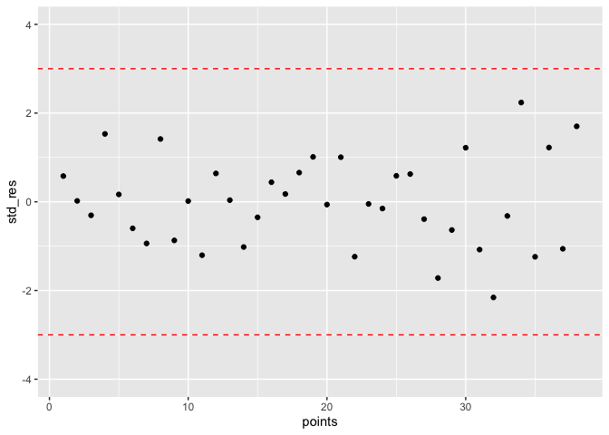

```r
ggplot(data = NULL, aes(x = points, y = std_res)) +
  geom_point() +
  ylim(c(-4,4)) +
  geom_hline(yintercept = c(-3, 3), colour = "red", linetype = "dashed")
```

```r
# there does not appear to be any outliers as all standardised residuals are less than 3
```

### Step 9. Leverage points.

Determine if there are any high leverage points that have the potential to influence the model.

```r
hats <- hatvalues(fit)
```

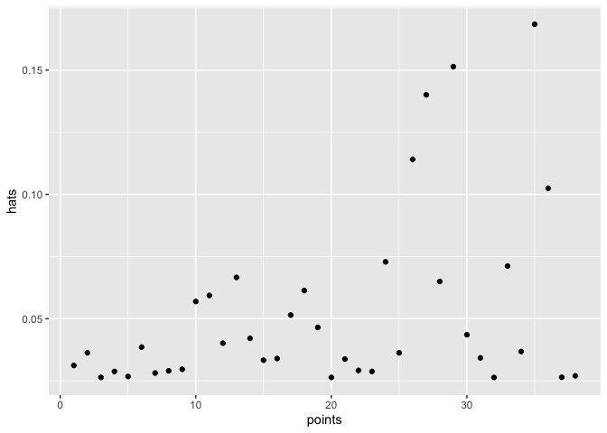

```r
ggplot(data = NULL, aes(x = points, y = hats)) +
  geom_point()
```

```r
# there are no hatvalues greater than 1, however we might investigate the points above 0.1
# as they seem to stick out above the rest
```

```r
hat_labels <- if_else(hats >= 0.10, paste(points), "")
```

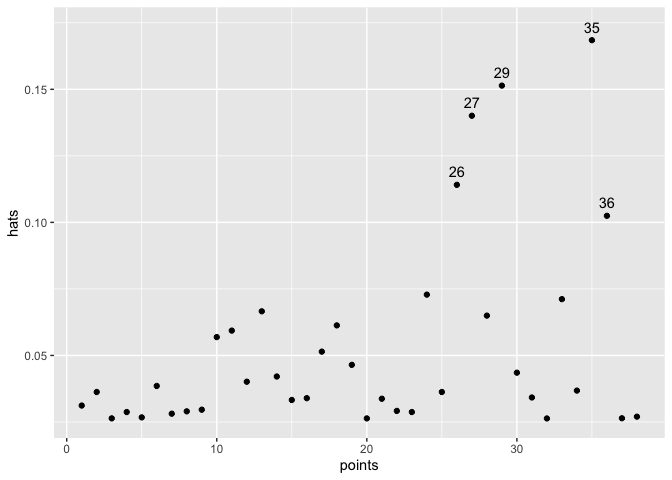

```r
ggplot(data = NULL, aes(x = points, y = hats)) +
  geom_point() +
  geom_text(aes(label = hat_labels), nudge_y = 0.005)
```

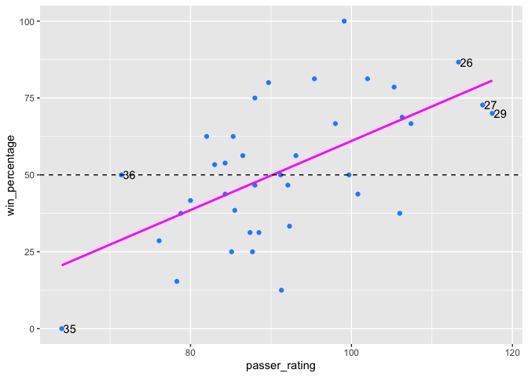

```r
ggplot(data = new_df, aes(x = passer_rating, y = win_percentage)) +
  geom_point(colour = "dodgerblue") +
  geom_smooth(method = "lm", colour = "magenta", se = FALSE) +
  geom_hline(yintercept = 50, colour = "black", linetype = "dashed") +
  geom_text(aes(label = hat_labels), nudge_x = 1)
```

### Step 10. Influential points.

Determine if any of the points could be considered as points of high influence.

```r
cook <- cooks.distance(fit)
```

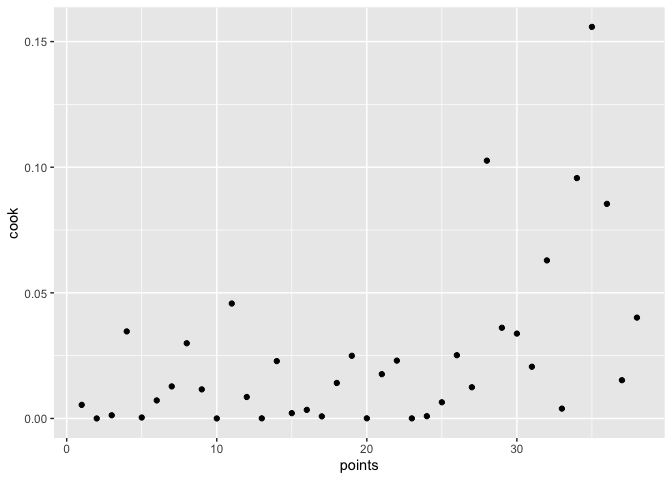

```r
ggplot(data = NULL, aes(x = points, y = cook)) +
  geom_point()
```

```r
cook_labels <- if_else(cook >= 0.015, paste(points), "")
```

```r
# we might take a look at those points above 0.05 that are standing out above the rest
```

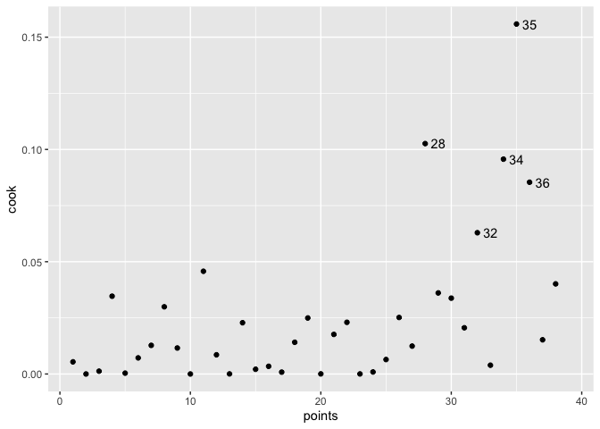

```r
cook_labels <- if_else(cook >= 0.05, paste(points), "")

ggplot(data = NULL, aes(x = points, y = cook)) +
  geom_point() +
  geom_text(aes(label = cook_labels), nudge_x = 1)
```

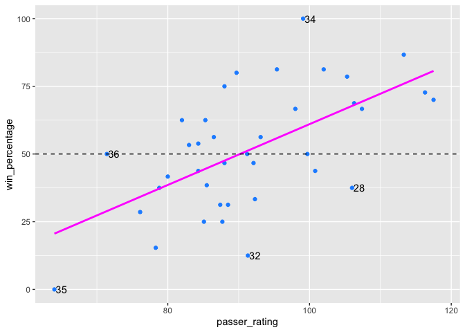

```r
ggplot(data = new_df, aes(x = passer_rating, y = win_percentage)) +
  geom_point(colour = "dodgerblue") +
  geom_smooth(method = "lm", colour = "magenta", se = FALSE) +
  geom_hline(yintercept = 50, colour = "black", linetype = "dashed") +
  geom_text(aes(label = cook_labels), nudge_x = 1)
```

```r
# there are 5 players that could be influencing the model
```

If you have determined there to be any points that are high influence, remove these from the data and re-run your linear regression model.

Does doing so make much of a difference to the model? Don’t forget to check the R-Squared value using the `summary()` function as well as checking the intercept and slope coefficients.

```r
# create new df without the high influence points

outliers <- c(28, 32, 34, 35, 36) # store case numbers to remove in object 'outliers'
filtered_df <- new_df %>%
  filter(!case_no %in% outliers)  # filter if case_no is not (!) %in% outliers
```

```r
# re-run the linear regression with filtered_df
fit2 <- lm(win_percentage ~ passer_rating, data = filtered_df)
tidy(fit2, conf.int = TRUE)
```

```
## # A tibble: 2 x 7
##   term          estimate std.error statistic   p.value conf.low conf.high
##   <chr>            <dbl>     <dbl>     <dbl>     <dbl>    <dbl>     <dbl>
## 1 (Intercept)     -49.4     22.4       -2.21 0.0349     -95.1       -3.75
## 2 passer_rating     1.11     0.241      4.62 0.0000637    0.621      1.60
```

```r
summary(fit2)
```

```
##
## Call:
## lm(formula = win_percentage ~ passer_rating, data = filtered_df)
##
## Residuals:
##      Min       1Q   Median       3Q      Max
## -23.1194 -11.2702  -0.7186  10.0687  29.6558
##
## Coefficients:
##               Estimate Std. Error t value Pr(>|t|)
## (Intercept)   -49.4421    22.4043  -2.207   0.0349 *
## passer_rating   1.1124     0.2408   4.620 6.37e-05 ***
## ---
## Signif. codes:  0 '***' 0.001 '**' 0.01 '*' 0.05 '.' 0.1 ' ' 1
##
## Residual standard error: 15.05 on 31 degrees of freedom
## Multiple R-squared:  0.4077, Adjusted R-squared:  0.3886
## F-statistic: 21.34 on 1 and 31 DF,  p-value: 6.37e-05
```

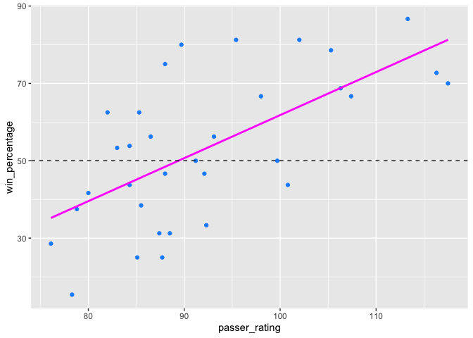

```r
# plot without the high influence points
ggplot(data = filtered_df, aes(x = passer_rating, y = win_percentage)) +
  geom_point(colour = "dodgerblue") +
  geom_smooth(method = "lm", colour = "magenta", se = FALSE) +
  geom_hline(yintercept = 50, colour = "black", linetype = "dashed")
```

```r
# both the slope and intercept coefficients haven't seemed to change too much
# the R-squared value has improved slightly, but perhaps not enough to warrent removing these points
```

### Step 11. Homoscedasticity.

Check your model for any evidence of heteroscedasticity.

```r
# we can test for heteroscedasticity by plotting the residuals against
# the fitted values
```

```r
res <- residuals(fit)
fitted <- predict(fit)  # or can use fitted()
```

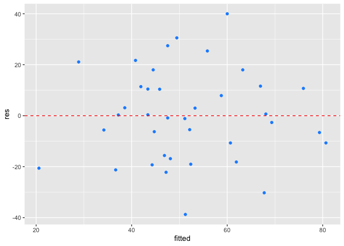

```r
ggplot(data = NULL, aes(x = fitted, y = res)) +
  geom_point(colour = "dodgerblue") +
  geom_hline(yintercept = 0, colour = "red", linetype = "dashed")
```

```r
# there does not appear to be evidence of heteroscedasticity
```

### Step 13. Normality.

Are the residuals of your model normally distributed?

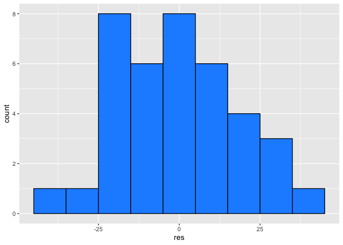

```r
ggplot(data = NULL, aes(x = res)) +
  geom_histogram(colour = "black", fill = "dodgerblue", binwidth = 10)
```

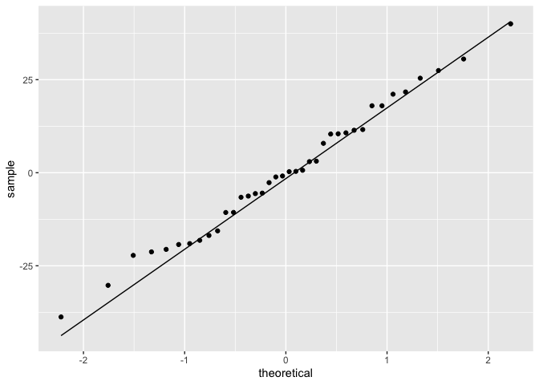

```r
ggplot(data = NULL, aes(sample = res)) +
  stat_qq() + stat_qq_line()
```

```r
# Perhaps some skewness, likely from the points that we investigated for influence.
# We already established they weren't doing too much damage to the overall results of the model,
# However to fix this possible non-normal distribution we should collect more data which will most likely solve this problem.
```

### Step 14. Interpretation.

Reconsider our original question. Have we been able to answer this adequately and what is the answer? Think about the real world application of this analysis, how can we use this information to select quarterbacks?

```r
# Quarterbacks with a higher passer rating tend to win more games, however the R-squared value of 36% indicates
# that there are other factors that contribute to winning and these should be investigated.
# On average, selecting a quarterback with a passer rating that is 10 units higher than the average quarterback, would have an # expected win_percentage that is 11% higher (multiplying the slope coef by 10)
# We should get more data though to be more confident in our model.
```

### Step 15. Push your changes.

Add, commit and push your local changes to your remote GitHub repository.

### Well done on completing this activity!